# Toothgrowth Analysis

## Summary

The data analyzed comes from the toothgrowth data in which the effects of vitamin c in response to tooth growth in guinea pigs were measured. There seems to be a difference in lower dosages for both vitamin c and orange juice, however larger dosages appeared to have yielded no difference in effects.

## Exploratory Analysis

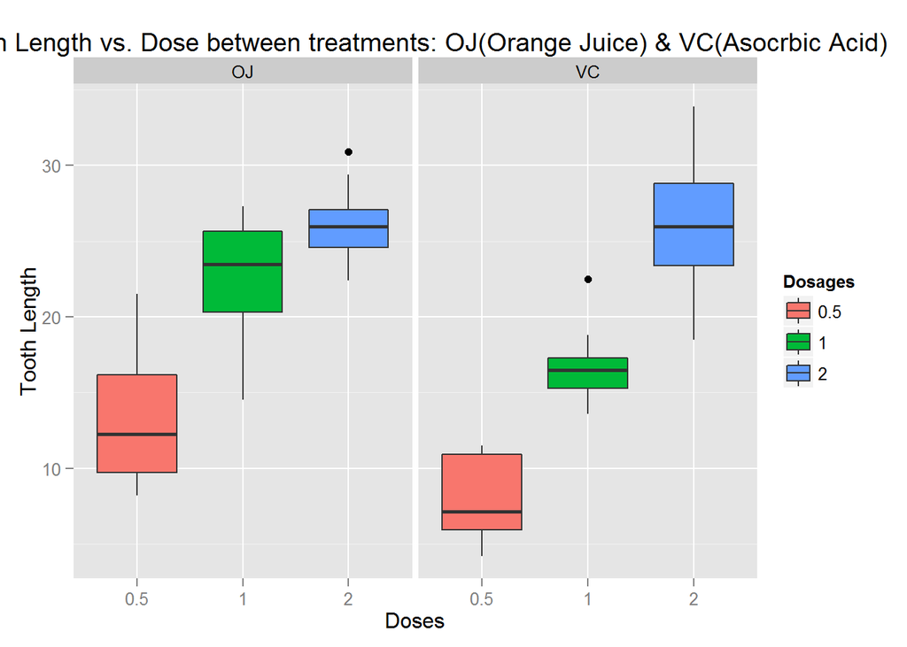

```r
data(ToothGrowth)

library(ggplot2)
ggplot(ToothGrowth, aes(x = factor(dose), y = len, fill = factor(dose))) +
       geom_boxplot() +
       facet_grid(.~supp) +
       labs(title = "Tooth Length vs. Dose between treatments: OJ(Orange Juice) & VC(Asocrbic Acid)",
       x = "Doses", y = "Tooth Length") +
       scale_fill_discrete(name="Dosages")
```

Preliminary analysis which shows from that the data that an increase in dosage tended to increase the tooth length of guninea pigs. There appears to be significant difference in the asorbic acid treatment in higher dosages and high variation within the orange juice set.

## Statistical Analysis

### CI 95% of dosage 0.5

```
##
##  Welch Two Sample t-test
##
## data:  ac and oj
## t = -3.1697, df = 14.969, p-value = 0.006359
## alternative hypothesis: true difference in means is not equal to 0
## 95 percent confidence interval:
##  -8.780943 -1.719057
## sample estimates:
## mean of x mean of y
##      7.98     13.23
```

The 95% confidence interval of dosage 0.5 is between -8.78 to -1.72. We are 95% confident that the true value between the two are in that range. The range does not encompass 0, meaning that there does seem to be a difference in the dosage of different supplements.

### CI 95% of dosage 1

```
##
##  Welch Two Sample t-test
##
## data:  ac and oj
## t = -4.0328, df = 15.358, p-value = 0.001038
## alternative hypothesis: true difference in means is not equal to 0
## 95 percent confidence interval:
##  -9.057852 -2.802148
## sample estimates:
## mean of x mean of y
##     16.77     22.70
```

The 95% confidence interval of dosage 1.0 is between -9.06 to -2.80. We are 95% confident that the true value between the two are in that range. The range does not encompass 0, meaning that there does seem to be a difference in the dosage of different supplements.

### CI 95% of dosage 2

```
##
##  Welch Two Sample t-test
##
## data:  ac and oj
## t = 0.0461, df = 14.04, p-value = 0.9639
## alternative hypothesis: true difference in means is not equal to 0
## 95 percent confidence interval:
##  -3.63807  3.79807
## sample estimates:
## mean of x mean of y
##     26.14     26.06
```

The 95% confidence interval of dosage 2.0 is between -3.64 to 3.8. We are 95% confident that the true value between the two are in that range. The range does encompasses 0, meaning that there might be no difference between the two supplements at a dosage of 2mg.

## Conclusion

In dosage 0.5 and 1, the effects exhibited the two different delivery methods, orange juice and asorbic acid, both apepared to have both increased the teeth length of the test guinea pigs. In dosage 0.5, the 95% confidence level were between -8.78 to -1.72, showing that the dosage seemed to have made an effect. In dosage 1.0, the 95% confidence level were between -9.06 to -2.8, meaning that we are 95% certain that the true difference is in the range and thus the treatment made a difference. In dosage of 2.0 however, the 95% confidence level were between -3.64 to 3.8, which means that the treatment at high dosages may be the same.